# B树

二叉树可以说是老伙计了，在还没学算法之前就老听到这个名字，到现在学习数据结构，这个东西可以说如影随行。

先前的顺序表（Sq_List）里，如果按顺序排好，查找的时间复杂度为O(logn)。但在插入O(n)和删除O(n)时及其麻烦，需要移位，于是链表尝试解决这个问题，改善了插入和删除时需要移位的问题，只需要指向就可以了。但查找就很麻烦了，无论是不是排好顺序的，查找都需要O(n)。

这时候，为什么不能存在那么一种东西，它即是顺序表又是链表呢？它即拥有顺序表的快速查找O(logn)，又拥有快速的插入和删除方法？这种东西就是今天要写的排序二叉树。

二叉树，顾名思义，有两个分叉，分叉上存有数据，而每个分叉又有自己的分叉，这样分叉下去就如同一颗繁密的大树，结着数不清的数据果实。

[figure not shown]

为了方便查找，我们做以下规定。

> - 分叉的那个节点，称为父母节点，它的分支，分别称为左孩子和右孩子
> - 左孩子比父母节点小，而右孩子比父母节点大

当我尝试访问查找是否有8这个数字时。先看父母节点10，10不是8，但我们知道8比10小，所以我们向左走；访问了3，发现还不是8，但8比3大，于是往右走；访问了4，发现4不是8，当8比4，于是往右走；访问了9，发现8比9小，于是往左走；发现了8。

整个访问看似繁琐，但其实都时重复的，就是不断的比较，选择下一条路，再比较。用**递归**的思想很好解决这个问题。

插入时，删除的方法和链表大同小异。

返回看一下上面的数，它是由高度的。它越高，我们去访问某一个节点时，平均花费的时间就越长，比较路径越来越长了嘛。当我们尝试插入或者删除一个节点时，会发现它的高度会产生变化，该如何调整它们的高度是我们今后需要研究的问题，但现在先不去考虑这些东西，先看看如何用python实现一棵普普通通的排序二叉树。

```python
"""
binary tree creat
"""

class Node():
    """
    节点类
    有三个属性，一个是节点本身存储的数据，另外两个分别是左右孩子的地址
    """

    def __init__(self, key):
        """
        :type key:number
        """
        self.key = key
        self.left = None
        self.right = None

class BinaryTree():
    """ 二叉树类 """

    def __init__(self):
        """
        任何一个二叉树都应该有一个根节点，初始化为 None
        """
        self.root = None

    def insert_node(self, node, new_node):
        '''
        :type node: Node
        :type new_node: Node

        插入一个新节点，如果后面没有节点了，后面的节点就是新节点的位置。反之，找到下一个节点。
        '''

        if new_node.key < node.key:
            if node.left is None:
                node.left = new_node
            else:
                return self.insert_node(node.left, new_node)
        else:
            if node.right is None:
                node.right = new_node
            else:
                return self.insert_node(node.right, new_node)


    def insert(self, key):
        ''' insert node '''

        new_node = Node(key)
        if self.root is None:
            self.root = new_node
        else:
            self.insert_node(self.root, new_node)

    def in_oder_traverse(self, node):
        ''' 中序遍历 '''

        if node is None:
            return []
        result = [node.key]
        left_result = self.in_oder_traverse(node.left)
        right_result = self.in_oder_traverse(node.right)
        return left_result + result + right_result

    def pre_oder_traverse(self, node):
        ''' 前序遍历 '''

        if node is None:
            return []
        result = [node.key]
        left_result = self.pre_oder_traverse(node.left)
        right_result = self.pre_oder_traverse(node.right)
        return result + left_result + right_result

    def post_oder_traverse(self, node):
        ''' 后序遍历 '''

        if node is None:
            return []
        result = [node.key]
        left_result = self.post_oder_traverse(node.left)
        right_result = self.post_oder_traverse(node.right)
        return left_result + right_result + result

    def search_node(self, node, key):
        '''
        :type node: Node
        :type key: number
        :rtype Bool

        查找是否存在某一个数
        '''
        if node is None:
            return False
        else:
            if key < node.key:
                return self.search_node(node.left, key)
            elif key > node.key:
                return self.search_node(node.right, key)
            else:
                return True

if __name__ == "__main__":
#     NODES = [8, 3, 10, 1, 6, 14, 4, 7, 13]
    NODES = [10, 3, 18, 2, 4, 13, 21, 9, 8, 9]
    BINARY_TREE = BinaryTree()
    for i in NODES:
        BINARY_TREE.insert(i)
    print(BINARY_TREE.in_oder_traverse(BINARY_TREE.root))
    print(BINARY_TREE.pre_oder_traverse(BINARY_TREE.root))
    print(BINARY_TREE.post_oder_traverse(BINARY_TREE.root))
    print(BINARY_TREE.search_node(BINARY_TREE.root, 7))
    print(BINARY_TREE.search_node(BINARY_TREE.root, 9))
```

```
[2, 3, 4, 8, 9, 9, 10, 13, 18, 21]
[10, 3, 2, 4, 9, 8, 9, 18, 13, 21]
[2, 8, 9, 9, 4, 3, 13, 21, 18, 10]
False
True
```

到这里，一颗简单的二叉树就大概完成了。

不过，在这里，这颗数的插入顺序是被精心设计好的，树的形状才会如此的完美，如果没有只是随意插入，很可能就会出现下面这幅图的情况。

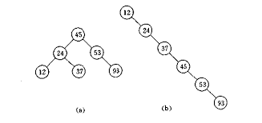

所有的数据都长到一边去，这就和一般的链表没什么区别了。除此以外，有些无聊的家伙，还是嫌树的查找效率不够高，恨不得一秒钟就能把整个宇宙算完。

为此，无聊的家伙们一点一点地衍生出了红黑树、B+、B-等各种树，这就是另外的故事了。